# Risk and protective factors for (internet) gaming disorder: A meta-analysis

Ivan Ropovik, Marcel Martončik, Gabriel Baník, Lenka Vargová, Peter Babinčák, & Matúš Adamkovič

2022-11-27

#### Appendix E: Analyses outputs

**This is the supplementary analytic output for the paper “Risk and protective factors for (internet) gaming disorder: A meta-analysis”.**

**It reports detailed results for all models reported in the paper. The analytic R script by which this html report was generated can be found on the project’s OSF page at: https://osf.io/zdmcy/.** **Preprint of the paper is available here: https://psyarxiv.com/pg3rf/, Appendices A-D are available here: https://osf.io/zdmcy/**

**Brief information about the methods used in the analysis:**

**RMA results with model-based SEs** k = number of studies; sqrt in “Variance components” = tau, the standard deviation of true effects; estimate in “Model results” = naive MA estimate

**RVE SEs with Satterthwaite small-sample correction** Estimate based on a multilevel RE model with constant sampling correlation model (CHE - correlated hierarchical effects - working model) (Pustejovsky & Tipton, 2020; https://osf.io/preprints/metaarxiv/vyfcj/). Interpretation of naive-meta-analysis should be based on these estimates.

**Prediction interval** Shows the expected range of true effects in similar studies. As an approximation, in 95% of cases the true effect in a new *published* study can be expected to fall between PI LB and PI UB. Note that these are non-adjusted estimates. An unbiased newly conducted study will more likely fall in an interval centered around bias-adjusted estimate with a wider CI width.

**Heterogeneity** Tau can be interpreted as the total amount of heterogeneity in the true effects. I^2 represents the ratio of true heterogeneity to total variance across the observed effect estimates. Estimates calculated by two approaches are reported. This is followed by separate estimates of between- and within-cluster heterogeneity and estimated intra-class correlation of underlying true effects.

**Proportion of significant results** What proportion of effects were statistically at the alpha level of .05.

**ES-precision correlation** Kendalls’s correlation between the ES and precision.

**4/3PSM** Applies a permutation-based, step-function 4-parameter selection model (one-tailed p-value steps = c(.025, .5, 1)). Falls back to 3-parameter selection model if at least one of the three p-value intervals contains less than 5 p-values. For this meta-analysis, we applied 3-parameter selection model by default as there were only 11 independent effects in the opposite direction overall (6%), causing the estimates to be unstable across iterations. pvalue = p-value testing H0 that the effect is zero. ciLB and ciUB are lower and upper bound of the CI. k = number of studies. steps = 3 means that the 4PSM was applied, 2 means that the 3PSM was applied. We also ran two sensitivity analyses of the selection model, the Vevea & Woods (2005) step function model with a priori defined selection weights and the Robust Bayesian Meta-analysis model employing the model-averaging approach (Bartoš & Maier, 2020).

**PET-PEESE** Estimated effect size of an infinitely precise study. Using 4/3PSM as the conditional estimator instead of PET (can be changed to PET). If the PET-PEESE estimate is in the opposite direction, the effect can be regarded nil. By default (can be changed to PET), the function employs a modified sample-size based estimator (see https://www.jepusto.com/pet-peese-performance/). It also uses the same RVE sandwich-type based estimator in a CHE (correlated hierarchical effects) working model with the identical random effects structure as the primary (naive) meta-analytic model.

We report results for both, PET and PEESE, with the first reported one being the primary (based on the conditional estimator).

**WAAP-WLS** The combined WAAP-WLS estimator (weighted average of the adequately powered - weighted least squares) tries to identify studies that are adequately powered to detect the meta-analytic effect. If there is less than two such studies, the method falls back to the WLS estimator (Stanley & Doucouliagos, 2015). If there are at least two adequately powered studies, WAAP returns a WLS estimate based on effects from only those studies.

type = 1: WAAP estimate, 2: WLS estimate. kAdequate = number of adequately powered studies

**p-uniform** P-uniform* is a selection model conceptually similar to p-curve. It makes use of the fact that p-values follow a uniform distribution at the true effect size while it includes also nonsignificant effect sizes. Permutation-based version of p-uniform method, the so-called p-uniform* (van Aert, van Assen, 2021).

**p-curve** Permutation-based p-curve method. Output should be self-explanatory. For more info see p-curve.com

**Handling of dependencies in bias-correction methods** To handle dependencies among the effects, the 4PSM, p-curve, p-uniform are implemented using a permutation-based procedure, randomly selecting only one focal effect (i.e., excluding those which were not coded as being focal) from a single study and iterating nIterations times. Lastly, the procedure selects the result with the median value of the ES estimate (4PSM, p-uniform) or median z-score of the full p-curve (p-curve).

# Descriptives

## Publication year

```
## from   to
## 2014 2020
```

## Sample sizes

### N of effects

```
## [1] 1586
```

### N of studies

```
##                          Studies overall
##                                      253
## Studies for which ES data were available
##                                      250
```

### N of papers

```
##                          Papers overall Papers for which ES data were available
##                                     210                                     207
```

### Median N across all the ES eligible for meta-analysis

```
## [1] 468
```

### Total meta-analytic N

```
## [1] 210557
```

## Proportion of effects in published papers

```
##
##         0         1
##  3.281734 96.718266
```

## Mean gender ratio (percent female)

```
##      Mean        SD
## 0.3323819 0.2081772
```

## Weighted mean age of included samples

```
## [1] 22.45824
```

## Proportion of sample types

1 = gamers other than esport; 2 = esport (competitive) gamers; 3 = general population; 4 = university students; 5 = clinical population; 6 = other

```
##
##         1         3         4         5         6
## 42.554517 26.043614 12.024922 11.090343  8.286604
```

## Proportion for GD criteria usage

Presence of the GD diagnostic category was based on: 1 = DSM5 ≥ 5 criteria; 2 = LCA cut off; 3 = no criteria used - IGD treated as interval variable; 4 = clinical assessmet; 5 = other type of criteria; integer

```
##
##          1          2          3          4          5
## 28.6864932  0.2478315 62.0198265  5.0185874  4.0272615
```

## GD measure used

```
##
##                                                      IGDS9-SF (Pontes & Griffiths, 2015)
##                                                                              20.63197026
##                                                                           DSM-5 criteria
##                                                                              15.92317224
##                                                                       clinical interview
##                                                                              11.52416357
##                                                 IGDS, dichotomous (Lemmens et al., 2015)
##                                                                              11.52416357
##                                                           IGDT-10 (KirГЎly et al., 2017)
##                                                                              11.15241636
##                                                                IGDC (Petry et al., 2014)
##                                                                               7.68277571
##                                                  IGDS, polytomous (Lemmens et al., 2015)
##                                                                               3.46964064
##                                                              IGD-20 (Pontes et al.,2014)
##                                                                               3.09789343
##                                   DSM-5 criteria + Internet Addiction Test (Young, 1998)
##                                                                               1.79677819
##                                                                   non-clinical interview
##                                                                               1.48698885
##         DSM-5 criteria semi-structured interview (Ko et al., 2014) + additional criteria
##                                                                               1.17719950
##                                                           C-IGDS (Sigerson et al., 2017)
##                                                                               0.99132590
##                                                              CSAS (Rehbein et al., 2015)
##                                                                               0.99132590
##                           Diagnostic interview for Internet Addiction (Ryu et al., 2019)
##                                                                               0.99132590
##                                         GDT - Gaming Disorder Test (Pontes et al., 2019)
##                                                                               0.80545229
##                                                              PIE-9 (Pearcy et al., 2016)
##                                                                               0.74349442
##                                                      DSM-5 + IGD-20 (Pontes et al.,2014)
##                                                                               0.55762082
##                                                          IAT + IGDC (Petry et al., 2014)
##                                                                               0.55762082
##                                                                 Przybylski et al. (2017)
##                                                                               0.49566295
##                                                           GADIS-A (Paschke et al., 2020)
```

[output cut: 14 more lines]

```
##                                                                               0.30978934
##                                                                          IGDS (Yu, 2016)
##                                                                               0.30978934
##                                                    DSM-5 criteria + additional criterion
##                                                                               0.24783147
##                                      IGDS, dichotomous (Lemmens et al., 2015) - modified
##                                                                               0.24783147
##                                 Digital Addiction Scale for Children (Hawi et al., 2019)
##                                                                               0.18587361
##                                several inclusion criteria followed by clinical interview
##                                                                               0.18587361
##                                     IGDS9-SF (Pontes & Griffiths, 2015) + DSM-5 criteria
##                                                                               0.06195787
##                        Internet Addiction Test (Young, 1998) + IGDC (Petry et al., 2014)
##                                                                               0.06195787
```

## Gaming style

1 = predominantly online; 2 = predominantly offline; 3 = not specified

```
##
##        1        2        3
## 28.06691  1.17720 70.75589
```

## Platform device used for gaming

1 = PC; 2 = console; 3 = mobile phone or tablet; 4 = multiple platforms; 5 = not specified

```
##
##          1          3          4          5
##  0.1239157  1.1152416  9.8513011 88.9095415
```

## Correlate type proportions

1 = demographic; 2 = social; 3 = psychological; 4 = environmental; 5 = other; integer

```
##
##                    demographic                 gaming-related
##                      15.675341                      13.506815
## maladaptive personality traits                          other
##                       5.762082                       4.708798
##                  psychological             psychopathological
##                      31.722429                      25.898389
##                         social
##                       2.726146
```

## Reason not used proportions

1 = GD not compatible with ICD11 or DSM5; 2 = data for computing the ES missing; 3 = not a bivariate relationship; 4 = product of other included variables (e.g., sumscore); 5 = other (e.g. abstract only, other language than ENG, not empirical study); integer

```
##
##         1         2         3         5
## 55.673759 12.765957  7.446809 24.113475
```

## Design used proportions

1 = cross-sectional; 2 = pre-existing groups; 3 = experiment; 4 = longitudinal; 5 = other; integer

```
##
##          1          2          3          4
## 78.5669782 16.7601246  0.5607477  4.1121495
```

## Possible CoI proportions

```
##
##         0         1
## 97.095179  2.904821
```

# Meta-analysis results for individual correlates

Number of iterations run equal to 100 for p-curve and 1000 for all other bias correction functions. For sensitivity analyses, we ran 100 iterations for the Vevea & Woods (2005) step function model. For supplementary robust bayesian model-averaging approach, we employed 4 MCMC chains with 1000 sampling iterations.

```
##                                  k          ES [95% CI] 95% PI [LB, UB]   SE
## age                            118  -0.01 [-0.04, 0.01]   [-0.25, 0.22] 0.01
## depression                      93     0.4 [0.36, 0.44]    [0.05, 0.75] 0.02
## gaming time                     87    0.38 [0.33, 0.42]   [-0.02, 0.77] 0.02
## being male                      78    0.18 [0.14, 0.21]   [-0.12, 0.48] 0.02
## anxiety (state)                 63    0.31 [0.27, 0.35]    [0.05, 0.57] 0.02
## internet addiction              53    0.59 [0.52, 0.65]    [0.15, 1.02] 0.03
## impulsivity                     29    0.38 [0.31, 0.45]    [0.03, 0.73] 0.03
## education                       24 -0.13 [-0.21, -0.04]   [-0.48, 0.23] 0.04
## social motive                   24    0.19 [0.11, 0.26]   [-0.15, 0.52] 0.04
## stress                          23    0.39 [0.32, 0.45]     [0.1, 0.68] 0.03
## time for internet use           21    0.41 [0.26, 0.57]   [-0.22, 1.05] 0.07
## competition/achievement motive  20    0.24 [0.19, 0.29]    [0.02, 0.46] 0.03
## hostility/aggressivity (trait)  19    0.37 [0.28, 0.45]    [0.02, 0.71] 0.04
## social support                  19  -0.04 [-0.15, 0.07]   [-0.48, 0.41] 0.05
## loneliness                      17    0.28 [0.22, 0.34]    [0.03, 0.53] 0.03
## gaming time weekdays            16    0.34 [0.21, 0.46]   [-0.16, 0.83] 0.06
## gaming time weekends            16    0.35 [0.22, 0.49]    [-0.19, 0.9] 0.06
## escape motive                   15    0.42 [0.34, 0.51]    [0.09, 0.75] 0.04
## life satisfaction               15 -0.13 [-0.19, -0.07]   [-0.36, 0.09] 0.03
## skill development motive        15    0.21 [0.14, 0.29]    [-0.07, 0.5] 0.04
## social networking addiction     15    0.39 [0.25, 0.52]   [-0.15, 0.92] 0.06
## fantasy motive                  14     0.32 [0.24, 0.4]    [0.03, 0.62] 0.04
## recreation motive               14    0.08 [0.02, 0.15]   [-0.16, 0.32] 0.03
## self-esteem                     14 -0.24 [-0.32, -0.15]   [-0.54, 0.07] 0.04
## gaming frequency                13    0.29 [0.19, 0.38]   [-0.05, 0.63] 0.04
## ADHD                            12    0.26 [0.15, 0.38]    [-0.1, 0.63] 0.05
## coping motive                   12       0.3 [0.2, 0.4]   [-0.05, 0.65] 0.05
## online gaming time              12    0.22 [0.15, 0.29]    [0.02, 0.42] 0.03
## intelligence                    11 -0.24 [-0.41, -0.07]   [-0.74, 0.26] 0.08
##                                 Tau I^2 % significant k for SMs.k
## age                            0.12 92%           38%          33
## depression                     0.18 97%           66%          75
## gaming time                     0.2 99%           86%          45
## being male                     0.15 97%           73%          35
## anxiety (state)                0.13 94%           59%          44
## internet addiction             0.21 99%           74%          33
## impulsivity                    0.17 95%           48%          23
## education                      0.17 92%            8%           4
## social motive                  0.15 97%           75%          19
```

[output cut: 155 more lines]

```
## loneliness                                                1
## gaming time weekdays                                      1
## gaming time weekends                                      1
## escape motive                                             1
## life satisfaction                                         1
## skill development motive                                  1
## social networking addiction                               1
## fantasy motive                                            1
## recreation motive                                         1
## self-esteem                                           0.998
## gaming frequency                                          1
## ADHD                                                  0.996
## coping motive                                             1
## online gaming time                                        1
## intelligence                                          0.535
```

## Detailed results for individual correlates

```
## $age
## $age$`RMA results with model-based SEs`
##
## Multivariate Meta-Analysis Model (k = 116; method: REML)
##
## Variance Components:
##
##             estim    sqrt  nlvls  fixed        factor
## sigma^2.1  0.0071  0.0841    116     no         study
## sigma^2.2  0.0071  0.0841    116     no  study/result
##
## Test for Heterogeneity:
## Q(df = 115) = 1324.6161, p-val < .0001
##
## Model Results:
##
## estimate      se     zval    pval    ci.lb   ci.ub
##  -0.0133  0.0126  -1.0535  0.2921  -0.0379  0.0114
##
## ---
## Signif. codes:  0 '***' 0.001 '**' 0.01 '*' 0.05 '.' 0.1 ' ' 1
##
##
## $age$`RVE SEs with Satterthwaite small-sample correction`
## $age$`RVE SEs with Satterthwaite small-sample correction`$test
##     Coef. Estimate     SE t-stat d.f. p-val (Satt) Sig.
## 1 intrcpt  -0.0133 0.0126  -1.05  107        0.295
##
## $age$`RVE SEs with Satterthwaite small-sample correction`$CIs
##      Coef Estimate     SE d.f. Lower 95% CI Upper 95% CI
## 1 intrcpt  -0.0133 0.0126  107      -0.0382       0.0117
##
##
## $age$`Prediction interval`
## 95% PI LB 95% PI UB
##    -0.250     0.224
##
## $age$Heterogeneity
##                           Tau                           I^2
##                     0.1189959                    91.9620816
```

[output cut: 3628 more lines]

```
## $intelligence$`Publication bias`$`p-curve`
## NULL
##
##
## $intelligence$`Power for detecting SESOI and bias-corrected parameter estimates`
##   Median.power.for.detecting.a.SESOI.of.r....10
## 1                                         0.101
##   Median.power.for.detecting.a.SESOI.of.r....30
## 1                                         0.535
##   Median.power.for.detecting.a.SESOI.of.r....50
## 1                                         0.953
##   Median.power.for.detecting.PET.PEESE.estimate
## 1                                         0.129
##   Median.power.for.detecting.4.3PSM.estimate
## 1                                         NA
```

#### Median width of prediction intervals

```
## [1] 0.676
```

## Meta-analysis plots (forest, funnel, p-curve plots)

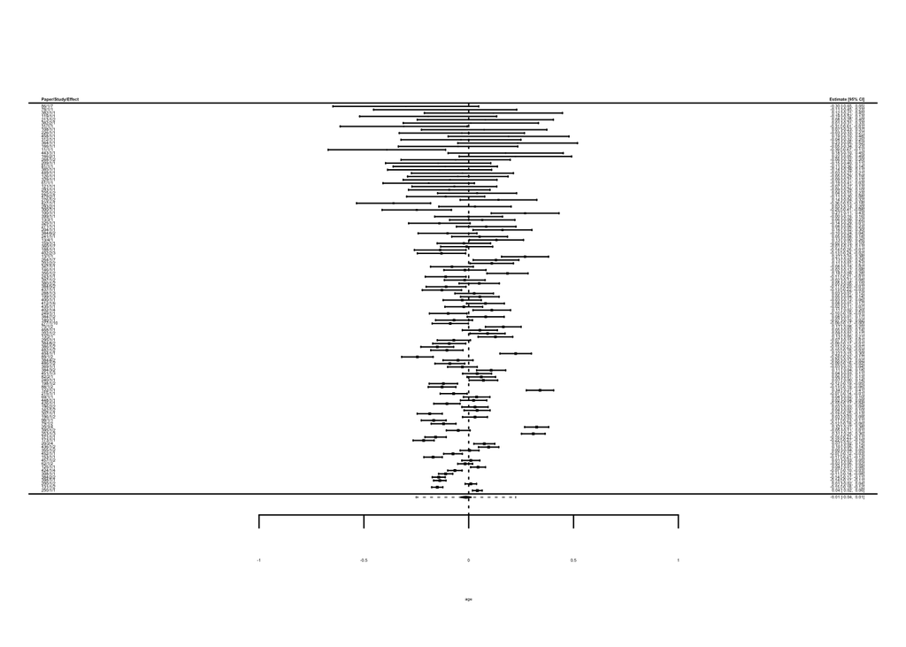

# Meta-analysis results for aggregated correlate types

## Comparison of correlate types

### Model without covariates

```
## $k
## correlateType
##                    demographic                 gaming-related
##                            253                            218
## maladaptive personality traits                          other
##                             93                             76
##                  psychological             psychopathological
##                            512                            418
##                         social
##                             44
##
## $test
##                                         Coef. Estimate     SE t-stat p-val (z)
## 1                    correlateTypedemographic   0.0855 0.0123   6.96    <0.001
## 2                 correlateTypegaming-related   0.3262 0.0196  16.65    <0.001
## 3 correlateTypemaladaptive personality traits   0.3296 0.0250  13.17    <0.001
## 4                          correlateTypeother   0.2761 0.0463   5.97    <0.001
## 5                  correlateTypepsychological   0.2403 0.0145  16.55    <0.001
## 6             correlateTypepsychopathological   0.3831 0.0154  24.86    <0.001
## 7                         correlateTypesocial   0.1799 0.0330   5.44    <0.001
##   Sig.
## 1  ***
## 2  ***
## 3  ***
## 4  ***
## 5  ***
## 6  ***
## 7  ***
##
## $CIs
##                                          Coef Estimate     SE d.f. Lower 95% CI
## 1                    correlateTypedemographic   0.0855 0.0123  Inf       0.0614
## 2                 correlateTypegaming-related   0.3262 0.0196  Inf       0.2878
## 3 correlateTypemaladaptive personality traits   0.3296 0.0250  Inf       0.2805
## 4                          correlateTypeother   0.2761 0.0463  Inf       0.1854
## 5                  correlateTypepsychological   0.2403 0.0145  Inf       0.2118
## 6             correlateTypepsychopathological   0.3831 0.0154  Inf       0.3529
## 7                         correlateTypesocial   0.1799 0.0330  Inf       0.1152
##   Upper 95% CI
## 1        0.110
## 2        0.365
## 3        0.379
## 4        0.367
## 5        0.269
## 6        0.413
## 7        0.245
##
## $`RVE Wald test`
##  test Fstat df_num df_denom  p_val sig
##   HTZ  45.3      4      102 <0.001 ***
```

### Model with covariates

Controlling for design-related factors that are prognostic w.r.t. the effect sizes (i.e., might vary across moderator categories).

```
## $test
##                                          Coef. Estimate      SE t-stat
## 1                     correlateTypedemographic  0.16688 0.05556  3.004
## 2                  correlateTypegaming-related  0.42629 0.05798  7.352
## 3  correlateTypemaladaptive personality traits  0.40073 0.05869  6.828
## 4                           correlateTypeother  0.36588 0.07434  4.922
## 5                   correlateTypepsychological  0.31544 0.05548  5.686
## 6              correlateTypepsychopathological  0.45941 0.05584  8.227
## 7                          correlateTypesocial  0.26203 0.06740  3.888
## 8                                      meanAge -0.00154 0.00183 -0.838
## 9                                   percFemale -0.12915 0.04670 -2.766
## 10                                 gamingStyle -0.02831 0.01133 -2.498
## 11                                  sampleType  0.02566 0.00705  3.639
##    p-val (z) Sig.
## 1    0.00267   **
```

[output cut: 40 more lines]

### Full results for correlate type subsets

```
##                                  k       ES [95% CI] 95% PI [LB, UB]   SE  Tau
## psychological                  512  0.23 [0.2, 0.26]   [-0.15, 0.61] 0.01 0.19
## psychopathological             418 0.41 [0.38, 0.44]       [0, 0.82] 0.02 0.21
## demographic                    253  0.08 [0.06, 0.1]   [-0.23, 0.38] 0.01 0.15
## gaming-related                 218 0.32 [0.29, 0.36]    [-0.1, 0.75] 0.02 0.21
## maladaptive personality traits  93 0.33 [0.29, 0.38]       [0, 0.66] 0.02 0.16
## other                           76 0.23 [0.15, 0.31]    [-0.3, 0.76] 0.04 0.26
## social                          44 0.17 [0.09, 0.24]   [-0.22, 0.56] 0.04 0.18
##                                I^2 % significant k for SMs.k 3PSM est [95% CI]
## psychological                  97%           65%         103 0.21 [0.15, 0.28]
## psychopathological             98%           66%         122 0.39 [0.34, 0.43]
## demographic                    96%           46%          49 0.15 [0.07, 0.22]
## gaming-related                 99%           68%          75  0.3 [0.22, 0.38]
## maladaptive personality traits 95%           61%          48 0.33 [0.28, 0.39]
## other                          99%           54%          25 0.28 [0.14, 0.41]
## social                         97%           64%          17 0.24 [0.14, 0.35]
##                                3PSM.pvalue V&W [moderate/severe/extreme]
## psychological                            0                0.18/0.13/0.05
## psychopathological                       0                0.38/0.37/0.35
## demographic                              0               0.07/0.02/-0.04
## gaming-related                           0                 0.3/0.27/0.22
## maladaptive personality traits           0                0.31/0.29/0.26
## other                                    0                0.18/0.11/0.01
## social                                   0                0.17/0.12/0.04
##                                    RoBMA [95% CI] PET-PEESE est [95% CI]
## psychological                      0.11 [0, 0.32]      0.22 [0.18, 0.25]
## psychopathological                 0.44 [0, 0.66]      0.36 [0.32, 0.39]
## demographic                        0.08 [0, 0.24]       0.07 [0.05, 0.1]
## gaming-related                 0.09 [-0.16, 0.55]      0.28 [0.24, 0.31]
## maladaptive personality traits      0.4 [0, 0.65]      0.26 [0.22, 0.31]
## other                                        <NA>     0.11 [-0.02, 0.25]
## social                             0.29 [0, 0.45]       0.21 [0.1, 0.32]
##                                PET-PEESE.pvalue Power to detect small SESOI
## psychological                                 0                       0.591
## psychopathological                            0                       0.393
## demographic                                   0                       0.605
## gaming-related                                0                        0.65
## maladaptive personality traits                0                       0.387
## other                                     0.101                       0.717
## social                                    0.001                       0.593
##                                Power to detect medium SESOI
## psychological                                             1
## psychopathological                                    0.999
## demographic                                               1
## gaming-related                                            1
## maladaptive personality traits                        0.999
## other                                                     1
## social                                                    1
```

## Detailed results for aggregated correlate types

```
## $psychological
## $psychological$`RMA results with model-based SEs`
##
## Multivariate Meta-Analysis Model (k = 376; method: REML)
##
## Variance Components:
##
##             estim    sqrt  nlvls  fixed        factor
## sigma^2.1  0.0137  0.1172    132     no         study
## sigma^2.2  0.0225  0.1500    376     no  study/result
##
## Test for Heterogeneity:
## Q(df = 375) = 14571.2517, p-val < .0001
##
## Model Results:
##
## estimate      se     zval    pval   ci.lb   ci.ub
##   0.2309  0.0145  15.9635  <.0001  0.2026  0.2593  ***
##
## ---
## Signif. codes:  0 '***' 0.001 '**' 0.01 '*' 0.05 '.' 0.1 ' ' 1
##
##
## $psychological$`RVE SEs with Satterthwaite small-sample correction`
## $psychological$`RVE SEs with Satterthwaite small-sample correction`$test
##     Coef. Estimate     SE t-stat d.f. p-val (Satt) Sig.
## 1 intrcpt    0.231 0.0145     16  117       <0.001  ***
##
## $psychological$`RVE SEs with Satterthwaite small-sample correction`$CIs
##      Coef Estimate     SE d.f. Lower 95% CI Upper 95% CI
## 1 intrcpt    0.231 0.0145  117        0.202         0.26
##
##
## $psychological$`Prediction interval`
## 95% PI LB 95% PI UB
##    -0.147     0.609
##
## $psychological$Heterogeneity
##                           Tau                           I^2
##                      0.190373                     97.409044
```

[output cut: 840 more lines]

```
## - Evidential value present: yes
## - Evidential value absent/inadequate: no
##
##
## $social$`Power for detecting SESOI and bias-corrected parameter estimates`
##   Median.power.for.detecting.a.SESOI.of.r....10
## 1                                         0.593
##   Median.power.for.detecting.a.SESOI.of.r....30
## 1                                             1
##   Median.power.for.detecting.a.SESOI.of.r....50
## 1                                             1
##   Median.power.for.detecting.PET.PEESE.estimate
## 1                                         0.996
##   Median.power.for.detecting.4.3PSM.estimate
## 1                                          1
```

#### Median width of prediction intervals

For individual risk factors

```
## [1] 0.676
```

For aggregated risk factor types

```
## [1] 0.778
```

## Summary forest plot

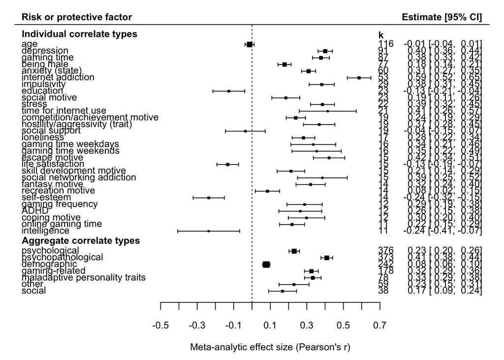

#### r ES converted to odds ratios

```
##                       Risk.factor                OR
## 1                             age 0.98 [0.93, 1.02]
## 2                      depression 2.07 [1.93, 2.22]
## 3                     gaming time 1.98 [1.82, 2.16]
## 4                      being male 1.38 [1.29, 1.47]
## 5                 anxiety (state) 1.75 [1.63, 1.88]
## 6              internet addiction 2.89 [2.57, 3.26]
## 7                     impulsivity    2 [1.76, 2.26]
## 8                       education 0.79 [0.68, 0.93]
## 9                   social motive  1.4 [1.22, 1.61]
## 10                         stress 2.01 [1.79, 2.27]
## 11          time for internet use  2.12 [1.6, 2.81]
## 12 competition/achievement motive   1.54 [1.4, 1.7]
## 13 hostility/aggressivity (trait) 1.95 [1.67, 2.28]
## 14                 social support 0.94 [0.77, 1.14]
```

[output cut: 22 more lines]

# Moderation analyses

## Substantive Moderators of GD

```
## $age
##              percFemale meanAge sampleType gdCriteria
## Mod estimate      0.020   0.000      0.010       0.00
## Qm stat           1.620   0.010      0.820       0.09
## df                1.000   1.000      1.000       1.00
## p                 0.204   0.908      0.364       0.77
##
## $depression
##              percFemale meanAge sampleType gdCriteria
## Mod estimate      -0.11   0.060      0.050      0.090
## Qm stat           12.97   2.830      9.420     10.860
## df                 1.00   1.000      1.000      1.000
## p                  0.00   0.092      0.002      0.001
##
## $`gaming time`
##              percFemale meanAge sampleType gdCriteria
## Mod estimate     -0.040  -0.050       0.08      0.010
## Qm stat           0.780   1.360      14.12      0.030
## df                1.000   1.000       1.00      1.000
## p                 0.378   0.244       0.00      0.863
##
## $`being male`
##              percFemale meanAge sampleType gdCriteria
## Mod estimate      0.060   -0.08       0.05      0.030
## Qm stat          11.140   24.06      18.64      0.950
## df                1.000    1.00       1.00      1.000
## p                 0.001    0.00       0.00      0.329
##
## $`anxiety (state)`
##              percFemale meanAge sampleType gdCriteria
## Mod estimate     -0.060   0.060      0.010      0.030
## Qm stat           8.810   7.080      1.330      2.510
## df                1.000   1.000      1.000      1.000
## p                 0.003   0.008      0.248      0.113
##
## $`internet addiction`
##              percFemale meanAge sampleType gdCriteria
## Mod estimate       -0.3  -0.050      0.070      0.050
## Qm stat            12.6   0.220      1.590      0.340
## df                  1.0   1.000      1.000      1.000
```

[output cut: 147 more lines]

```
## p                 0.436    0.81      0.993      0.468
##
## $`online gaming time`
##              percFemale meanAge sampleType gdCriteria
## Mod estimate     -0.070    0.04     -0.040      0.020
## Qm stat           6.780    0.40      1.840      0.350
## df                1.000    1.00      1.000      1.000
## p                 0.009    0.53      0.175      0.554
##
## $intelligence
##              percFemale meanAge sampleType gdCriteria
## Mod estimate     -0.080   0.050     -0.010     -0.040
## Qm stat           0.850   0.350      0.080      0.340
## df                1.000   1.000      1.000      1.000
## p                 0.356   0.552      0.775      0.562
```

## Heatplot for substantive moderators

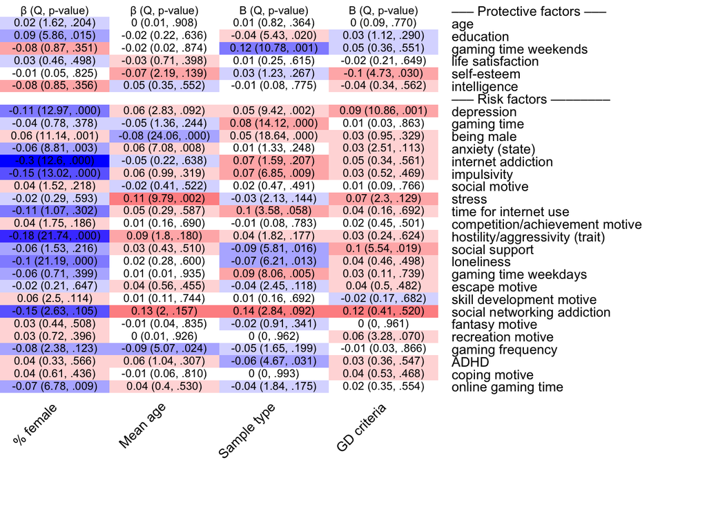

## Methodological moderators

### F-test of equality of variances for designs employing restricted vs unrestricted samples

#### Mean vi for restricted designs

```
## [1] 0.007782197
```

#### Mean vi for non-restricted designs

```
## [1] 0.003538576
```

#### F-test

```
##        F        p
## 2.199245 0.000000
```

### Year of Publication

Linear mixed-effects model. Taking into effect clustering of ESs due to originating from the same study. Using square root of variance to make the distribution normal.

```
##                     Estimate Std. Error       df    t value  Pr(>|t|)
## (Intercept)      -0.02364206 0.06262718 232.6074 -0.3775049 0.7061427
## scale(journalH5)  0.09572934 0.06210308 233.9157  1.5414588 0.1245569
## scale(pubYear)   -0.08325521 0.06195838 234.2753 -1.3437280 0.1803363
```

Comment: all the variables were centered for easier interpretation of model coefficients.

#### Scatterplot year <-> precision

Size of the points indicate the H5 index (the bigger the higher) of the journal that the ES is published in.

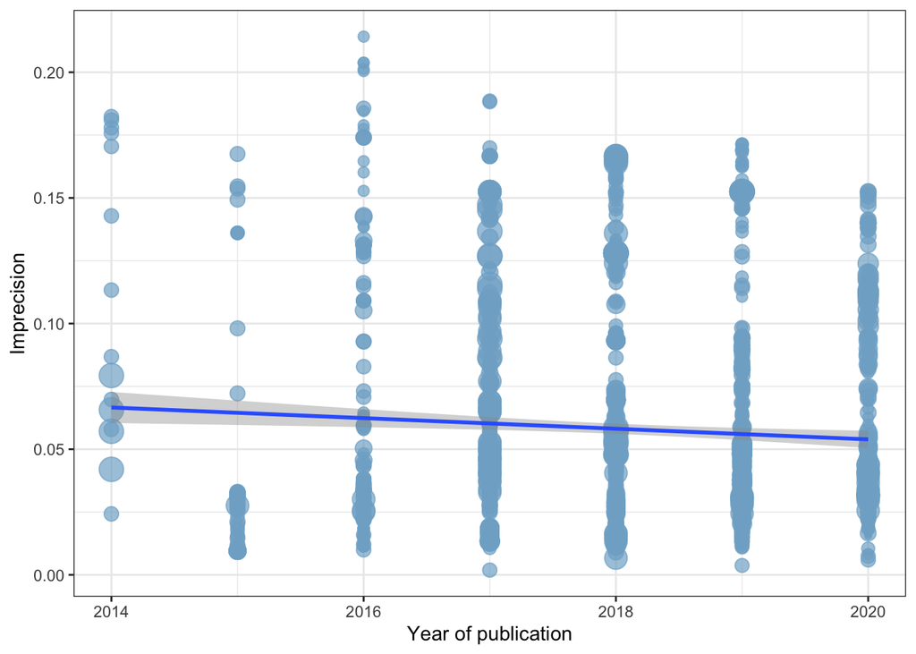

### Citations

Linear mixed-effects model. Taking into effect clustering of ESs due to originating from the same study. Using square root of variance to make the distribution normal.

```
##                      Estimate Std. Error       df     t value     Pr(>|t|)
## (Intercept)      -0.004598233 0.06140200 231.3894 -0.07488735 0.9403690447
## scale(pubYear)   -0.225859294 0.07295712 231.5165 -3.09578150 0.0022049147
## scale(journalH5)  0.145991545 0.06232610 230.6379  2.34238214 0.0200126815
## scale(citations) -0.233583628 0.06676512 234.3702 -3.49858780 0.0005595689
```

#### Scatterplot precision <-> citations

The relationship between precision (sqrt of variance) and number of citations (log).

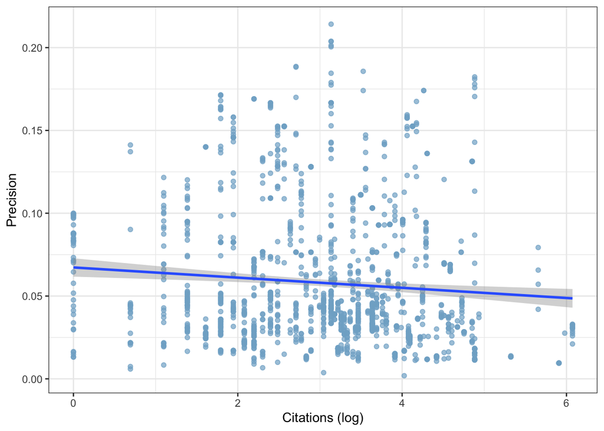

### H5 index

Linear mixed-effects model. Taking into effect clustering of ESs due to originating from the same study. Using square root of variance to make the distribution normal.

```
##                     Estimate Std. Error       df    t value   Pr(>|t|)
## (Intercept)      -0.02394236 0.06273881 233.6348 -0.3816195 0.70309043
## scale(journalH5)  0.11290047 0.06088096 237.2457  1.8544463 0.06491623
```

#### Scatterplot precision <-> journal H5

The relationship between precision (sqrt of variance) and H5 index of the journal.

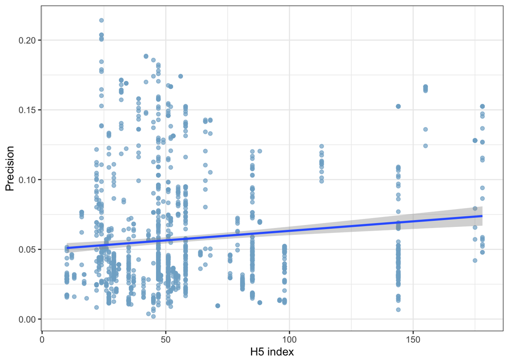

### Decline effect

Linear mixed-effects model. Taking into effect clustering of ESs due to originating from the same study.

```
##                    Estimate Std. Error       df    t value
## (Intercept)     -0.04085978 0.09262475  150.279 -0.4411324
## scale(sqrt(vi))  1.24757906 0.04856478 1422.718 25.6889675
## scale(pubYear)   0.16233356 0.09091662  154.972  1.7855212
##                                                                                                                                         Pr(>|t|)
## (Intercept)     0.659751154423149688277305813244311138987541198730468750000000000000000000000000000000000000000000000000000000000000000000000000
## scale(sqrt(vi)) 0.000000000000000000000000000000000000000000000000000000000000000000000000000000000000000000000000000000000000000000000007037723
## scale(pubYear)  0.076132544132708701578593490921775810420513153076171875000000000000000000000000000000000000000000000000000000000000000000000000
```

### Citation bias

Do more highly-cited studies report larger effect sizes?

```
##                      Estimate  Std. Error       df    t value
## (Intercept)       0.287539862 0.008562158 193.6477 33.5826387
## scale(pubYear)   -0.019622398 0.010227338 199.8664 -1.9186223
## scale(journalH5) -0.006792298 0.008616302 186.8067 -0.7883079
## scale(citations) -0.017673556 0.009498130 203.5335 -1.8607406
##                                                                                                    Pr(>|t|)
## (Intercept)      0.0000000000000000000000000000000000000000000000000000000000000000000000000000000001089852
## scale(pubYear)   0.0564569973535182789703412709059193730354309082031250000000000000000000000000000000000000
## scale(journalH5) 0.4315158393199389763594808755442500114440917968750000000000000000000000000000000000000000
## scale(citations) 0.0642230819458369378560647078302281443029642105102539062500000000000000000000000000000000
```

Additionally taking into account precision of the effect (vi)

```
##                      Estimate  Std. Error       df     t value
## (Intercept)       0.293197031 0.014197612 128.7881  20.6511517
## scale(pubYear)   -0.058964700 0.017018847 132.5260  -3.4646706
## scale(journalH5)  0.009439562 0.014424880 128.4678   0.6543945
## scale(citations) -0.054261869 0.015664369 136.3218  -3.4640316
## scale(vi)        -0.160119976 0.008817833 982.6238 -18.1586528
##                                                                                  Pr(>|t|)
## (Intercept)      0.0000000000000000000000000000000000000000010883449245297372822118258363
## scale(pubYear)   0.0007156769490452465206850596324272828496759757399559020996093750000000
## scale(journalH5) 0.5140274917036662394309587398311123251914978027343750000000000000000000
## scale(citations) 0.0007116129224822628079882846918735594954341650009155273437500000000000
## scale(vi)        0.0000000000000000000000000000000000000000000000000000000000000009186312
```

# Sensitivity analyses

## Corrections of statistical artifacts

Corrections for measurement error and selection effects Indirect selection bias not adjusted for intelligence due to low k + missing reliability data

[output not shown]

#### Full results

```
## $`Correcting for measurement error in both, GD and correlate`
##                                  k     N      mean_r    mean_rho     sd_rho
## age                            116 93098 -0.02928453 -0.03093505 0.11457629
## depression                      91 54710  0.34407035  0.37834724 0.07682741
## gaming time                     87 76751  0.32303701  0.35409229 0.11519129
## being male                      77 95162  0.14526550  0.15199874 0.15652998
## anxiety (state)                 60 39584  0.32928111  0.37247901 0.09811897
## internet addiction              53 29870  0.41497866  0.32295134 0.04084058
## impulsivity                     29 19314  0.30044055  0.38030784 0.00000000
## education                       23 11736 -0.03475912 -0.04130421 0.10228705
## social motive                   23 27552  0.16018429  0.22292228 0.14558866
## stress                          22 11475  0.44191472  0.41495098 0.10418348
## time for internet use           21 17108  0.45761528  0.51134917 0.26169158
## competition/achievement motive  19 26310  0.20664910  0.30615835 0.13312536
## hostility/aggressivity (trait)  19  9331  0.32104965  0.23918721 0.04098676
## social support                  19 17579  0.06040473  0.13038608 0.42205676
## loneliness                      17 22825  0.31222243  0.35142949 0.03584904
## gaming time weekdays            16  9435  0.24381653  0.22104884 0.10965465
## gaming time weekends            16  9480  0.25265624  0.22706652 0.14060604
## escape motive                   15 22967  0.39357509  0.50252794 0.18674728
## life satisfaction               15 16373 -0.12893775 -0.10440207 0.05919409
## skill development motive        15 20368  0.16741751  0.21982651 0.12763097
## social networking addiction     15 12028  0.48115217  0.57924428 0.28622350
## fantasy motive                  14 20153  0.29173044  0.35677835 0.14938436
## recreation motive               14 22805  0.06155170  0.07931946 0.12264661
## self-esteem                     14  6504 -0.23661985 -0.22851461 0.11306422
## gaming frequency                12 20323  0.19663360  0.23233322 0.17741095
## ADHD                            12  7590  0.29133128  0.38696212 0.15936804
## coping motive                   12 21838  0.24784016  0.33198811 0.14795229
## online gaming time              11 17669  0.21395401  0.21980683 0.05536862
## intelligence                    11   574 -0.23671836 -0.23671836 0.24189228
##                                    CI_LL_95     CI_UL_95
## age                            -0.053142546 -0.008731934
## depression                      0.348849822  0.408146059
## gaming time                     0.322627102  0.385545437
## being male                      0.114801800  0.189264864
## anxiety (state)                 0.331396053  0.413933255
## internet addiction              0.275206393  0.374400451
## impulsivity                     0.338434990  0.422105135
## education                      -0.091139721  0.008556238
```

[output cut: 68 more lines]

```
## loneliness                      0.251613146  0.384805144
## gaming time weekdays            0.140554396  0.277257370
## gaming time weekends            0.132823968  0.296464163
## escape motive                   0.354561611  0.556944719
## life satisfaction              -0.127483566 -0.057342546
## skill development motive        0.128427828  0.265426026
## social networking addiction     0.348515117  0.667482337
## fantasy motive                  0.237288652  0.403623081
## recreation motive               0.004992483  0.137675657
## self-esteem                    -0.288448927 -0.132393069
## gaming frequency                0.105577674  0.311550742
## ADHD                            0.253326079  0.454294207
## coping motive                   0.208018376  0.388408187
## online gaming time              0.156996955  0.232961892
## intelligence                   -0.421865309 -0.051571420
```

#### Just the estimates + delta

```
##                           rowname          r        rho         diff
## 1                             age 0.02928453 0.02767931  0.001605221
## 2                      depression 0.34407035 0.33969359  0.004376753
## 3                     gaming time 0.32303701 0.32501998 -0.001982967
## 4                      being male 0.14526550 0.13645838  0.008807120
## 5                 anxiety (state) 0.32928111 0.33735295 -0.008071838
## 6              internet addiction 0.41497866 0.28568917  0.129289491
## 7                     impulsivity 0.30044055 0.33994309 -0.039502536
## 8                       education 0.03475912 0.03669052 -0.001931394
## 9                   social motive 0.16018429 0.19989308 -0.039708789
## 10                         stress 0.44191472 0.38062837  0.061286355
## 11          time for internet use 0.45761528 0.45427431  0.003340961
## 12 competition/achievement motive 0.20664910 0.27552845 -0.068879349
## 13 hostility/aggressivity (trait) 0.32104965 0.21593812  0.105111530
## 14                 social support 0.06040473 0.12563096 -0.065226231
## 15                     loneliness 0.31222243 0.31771515 -0.005492714
## 16           gaming time weekdays 0.24381653 0.20834165  0.035474884
## 17           gaming time weekends 0.25265624 0.21375026  0.038905984
## 18                  escape motive 0.39357509 0.45710342 -0.063528333
## 19              life satisfaction 0.12893775 0.09202318  0.036914567
## 20       skill development motive 0.16741751 0.19734209 -0.029924578
## 21    social networking addiction 0.48115217 0.50704964 -0.025897469
## 22                 fantasy motive 0.29173044 0.32033041 -0.028599967
## 23              recreation motive 0.06155170 0.07136692 -0.009815221
## 24                    self-esteem 0.23661985 0.20855336  0.028066496
## 25               gaming frequency 0.19663360 0.20896216 -0.012328567
## 26                           ADHD 0.29133128 0.35554810 -0.064216820
## 27                  coping motive 0.24784016 0.29921294 -0.051372781
## 28             online gaming time 0.21395401 0.19488945  0.019064561
## 29                   intelligence 0.23671836 0.23671836  0.000000000
```

## Using Fisher’s z instead of untransformed r

```
##                                pred        ci.lb      ci.ub       pi.lb
## age                            -0.01223093 -0.0372314 0.01278484  -0.2435255
## depression                     0.4207393   0.3692405  0.469662    -0.1089786
## gaming time                    0.4163218   0.3485628  0.4797518   -0.2453936
## being male                     0.1813235   0.1449818  0.2171766   -0.1308292
## anxiety (state)                0.3109081   0.2715326  0.3492446   0.03747742
## internet addiction             0.6752897   0.5577568  0.7662731   -0.4632123
## impulsivity                    0.4001631   0.3141994  0.4796182   -0.08045167
## education                      -0.1206923  -0.2031014 -0.03658535 -0.4243336
## social motive                  0.187756    0.1109724  0.2623113   -0.14867
## stress                         0.3889657   0.3186105  0.4550587   0.05147362
## time for internet use          0.4481708   0.2783132  0.5908464   -0.3040218
## competition/achievement motive 0.2403545   0.1878147  0.2915227   0.01768665
## hostility/aggressivity (trait) 0.3867684   0.279902   0.484167    -0.0850021
## social support                 -0.03573611 -0.1428148 0.07216946  -0.4571226
## loneliness                     0.2845174   0.2203798  0.3462053   0.01579619
## gaming time weekdays           0.349127    0.2148016  0.4704893   -0.217294
## gaming time weekends           0.3768927   0.22418    0.5115397   -0.2749202
## escape motive                  0.4270313   0.3456255  0.5020575   0.08831712
## life satisfaction              -0.133616   -0.1919849 -0.07430505 -0.3455496
## skill development motive       0.2127866   0.1372797  0.2858348   -0.0769374
## social networking addiction    0.4212604   0.2543423  0.5638069   -0.2933187
## fantasy motive                 0.3224386   0.24387    0.3968022   0.02024162
## recreation motive              0.08517786  0.01810693 0.1514856   -0.1575745
## self-esteem                    -0.2384456  -0.3209524 -0.1523469  -0.5088271
## gaming frequency               0.2927883   0.1932897  0.386326    -0.06859206
## ADHD                           0.2707768   0.1494477  0.3840726   -0.1273796
## coping motive                  0.3008214   0.1994599  0.3958136   -0.06833527
## online gaming time             0.2125908   0.1474558  0.2758898   0.02057575
## intelligence                   -0.2521062  -0.4223781 -0.06464816 -0.6854531
##                                pi.ub      cr.lb       cr.ub
## age                            0.2203799  -0.2435255  0.2203799
## depression                     0.7643492  -0.1089786  0.7643492
## gaming time                    0.8133926  -0.2453936  0.8133926
## being male                     0.4607674  -0.1308292  0.4607674
## anxiety (state)                0.5410265  0.03747742  0.5410265
## internet addiction             0.972811   -0.4632123  0.972811
## impulsivity                    0.729806   -0.08045167 0.729806
## education                      0.207348   -0.4243336  0.207348
## social motive                  0.4852285  -0.14867    0.4852285
## stress                         0.6467215  0.05147362  0.6467215
## time for internet use          0.856155   -0.3040218  0.856155
## competition/achievement motive 0.4403075  0.01768665  0.4403075
## hostility/aggressivity (trait) 0.7168799  -0.0850021  0.7168799
## social support                 0.3987528  -0.4571226  0.3987528
## loneliness                     0.5149064  0.01579619  0.5149064
## gaming time weekdays           0.7396529  -0.217294   0.7396529
## gaming time weekends           0.7913542  -0.2749202  0.7913542
## escape motive                  0.6772263  0.08831712  0.6772263
## life satisfaction              0.09128664 -0.3455496  0.09128664
## skill development motive       0.4693734  -0.0769374  0.4693734
## social networking addiction    0.8338498  -0.2933187  0.8338498
## fantasy motive                 0.5706513  0.02024162  0.5706513
## recreation motive              0.3182224  -0.1575745  0.3182224
## self-esteem                    0.07475539 -0.5088271  0.07475539
## gaming frequency               0.5862457  -0.06859206 0.5862457
## ADHD                           0.5937765  -0.1273796  0.5937765
## coping motive                  0.5975237  -0.06833527 0.5975237
## online gaming time             0.3894807  0.02057575  0.3894807
## intelligence                   0.3131255  -0.6854531  0.3131255
```

## Numerical inconsistencies in reported p-values

#### how many results were analyzed

```
## [1] 264
```

#### how many papers reported results in APA format

```
## [1] 0.1400966
```

#### how many % statcheck errors

```
##
##    FALSE     TRUE
## 85.98485 14.01515
```

#### how many % statcheck errors affected the decision

```
##     TRUE
## 10.81081
```

#### How many % papers contained statcheck errors

```
## [1] 27.58621
```

## p-curve for the full literature

```
## P-curve analysis
##  -----------------------
## - Total number of provided studies: k = 187
## - Total number of p<0.05 studies included into the analysis: k = 160 (85.56%)
## - Total number of studies with p<0.025: k = 152 (81.28%)
##
## Results
##  -----------------------
##                     pBinomial   zFull pFull   zHalf pHalf
## Right-skewness test         0 -68.285     0 -68.445     0
## Flatness test               1  62.342     1  67.045     1
## Note: p-values of 0 or 1 correspond to p<0.001 and p>0.999, respectively.
## Power Estimate: 99% (99%-99%)
##
## Evidential value
##  -----------------------
## - Evidential value present: yes
## - Evidential value absent/inadequate: no
```

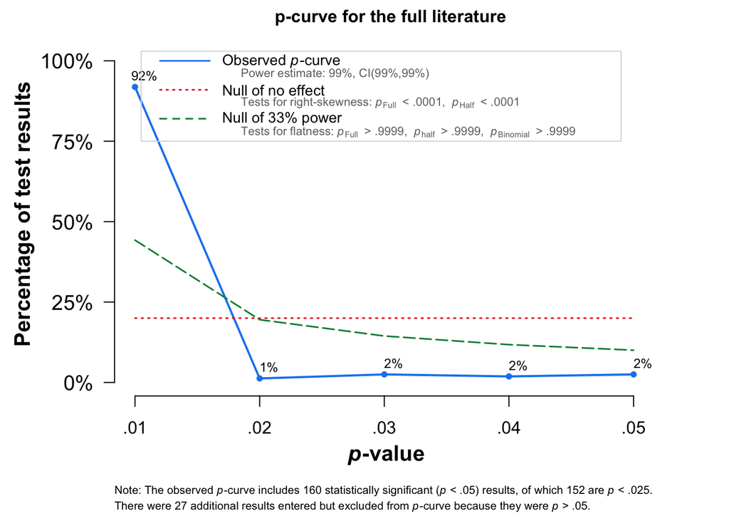

## Power for the full literature

```
##   Median.power.for.detecting.a.SESOI.of.r....10
## 1                                         0.581
##   Median.power.for.detecting.a.SESOI.of.r....30
## 1                                             1
##   Median.power.for.detecting.a.SESOI.of.r....50
## 1                                             1
##   Median.power.for.detecting.PET.PEESE.estimate
## 1                                Not calculated
##   Median.power.for.detecting.4.3PSM.estimate
## 1                             Not calculated
```

Script running time

```
## Time difference of 8.512593 hours
```